# Udacity CarND Term 1 - Vehicle Detection Project

The goals / steps of this project are the following:

- Perform a Histogram of Oriented Gradients (HOG) feature extraction on a labeled training set of images and train a classifier Linear SVM classifier
- Optionally, you can also apply a color transform and append binned color features, as well as histograms of color, to your HOG feature vector.
- Note: for those first two steps don't forget to normalize your features and randomize a selection for training and testing.
- Implement a sliding-window technique and use your trained classifier to search for vehicles in images.
- Run your pipeline on a video stream (start with the test_video.mp4 and later implement on full project_video.mp4) and create a heat map of recurring detections frame by frame to reject outliers and follow detected vehicles.
- Estimate a bounding box for vehicles detected.

Note: Experimentation showed that color features didn't affect the results of the classifier much, so I decided to run a classifier based just on HOG to sacrifice the minute difference in accuracy for the time so that feature extraction wouldn't be expensive on video/image streams.

## Setup

```python
from skimage.feature import hog
from sklearn.svm import LinearSVC
from sklearn.preprocessing import StandardScaler
from sklearn.model_selection import train_test_split
from scipy.ndimage.measurements import label
import matplotlib.image as mpimg
import matplotlib.pyplot as plt
from moviepy.editor import VideoFileClip
from IPython.display import HTML
import numpy as np
import pickle
import cv2
import glob
import time

%matplotlib inline
```

```python
car_images = glob.glob('training_dataset/vehicles/**/*.png')
noncar_images = glob.glob('training_dataset/non-vehicles/**/*.png')
print(len(car_images), len(noncar_images))
```

```
8792 8968
```

## 1. HOG feature extraction

```python
# img to hog
def get_hog_features(img, orient, pix_per_cell, cell_per_block,
                        vis=False, feature_vec=True):
    if vis == True:
        features, hog_image = hog(img, orientations=orient,
                                  pixels_per_cell=(pix_per_cell, pix_per_cell),
                                  cells_per_block=(cell_per_block, cell_per_block),
                                  transform_sqrt=False,
                                  visualise=vis, feature_vector=feature_vec)
        return features, hog_image
    else:
        features = hog(img, orientations=orient,
                       pixels_per_cell=(pix_per_cell, pix_per_cell),
                       cells_per_block=(cell_per_block, cell_per_block),
                       transform_sqrt=False,
                       visualise=vis, feature_vector=feature_vec)
        return features
```

After some experimentation, I found that the YUV colorspace with all channels, 9 orientations, 8x8 px per cell, and 2x2 cells per block worked pretty well.

```python
# full image set extraction
def extract_features(imgs):
    features = []
    for file in imgs:
        image = mpimg.imread(file)
        hog_features = []
        yuv = cv2.cvtColor(image, cv2.COLOR_RGB2YUV)
        for channel in range(yuv.shape[2]):
            hog_features.append(get_hog_features(yuv[:,:,channel], 9, 8, 2, vis=False, feature_vec=True))
        hog_features = np.ravel(hog_features)
        features.append(hog_features)
    return features
```

## 2. Extract features

```python
car_features = extract_features(car_images)
notcar_features = extract_features(noncar_images)

X = np.vstack((car_features, notcar_features)).astype(np.float64)

# Fit a per-column scaler - this will be necessary if combining different types of features (HOG + color_hist/bin_spatial)
X_scaler = StandardScaler().fit(X)
# Apply the scaler to X
X = X_scaler.transform(X)

# Define the labels vector
y = np.hstack((np.ones(len(car_features)), np.zeros(len(notcar_features))))

X_train, X_test, y_train, y_test = train_test_split(
    X, y, test_size=0.2, random_state=42)
```

## 3. Train model & test accuracy

```python
svc = LinearSVC()
svc.fit(X_train, y_train)
print('Test Accuracy of SVC = ', round(svc.score(X_test, y_test), 4))
print(X_train.shape)
```

```
Test Accuracy of SVC =  0.9811
(14208, 5292)
```

## 4. Code for detection pipeline

```python
# from lesson
# Define a single function that can extract features using hog sub-sampling and make predictions
def find_cars(img, ystart, ystop, scale, xstart=None, xstop=None):

    orient = 9
    pix_per_cell = 8
    cell_per_block = 2

    # array of rectangles where cars were detected
    rectangles = []

    img = img.astype(np.float32)/255

    img_tosearch = img[ystart:ystop,:,:]

    if xstart != None:
        img_tosearch = img_tosearch[:,xstart:xstop,:]
    else:
        xstart=0
    ctrans_tosearch = cv2.cvtColor(img_tosearch, cv2.COLOR_RGB2YUV)

    # rescale image if other than 1.0 scale
    if scale != 1:
        imshape = ctrans_tosearch.shape
        ctrans_tosearch = cv2.resize(ctrans_tosearch, (np.int(imshape[1]/scale), np.int(imshape[0]/scale)))

    ch1 = ctrans_tosearch[:,:,0]
    ch2 = ctrans_tosearch[:,:,1]
    ch3 = ctrans_tosearch[:,:,2]

    # Define blocks and steps as above
    nxblocks = (ch1.shape[1] // pix_per_cell)+1  #-1
    nyblocks = (ch1.shape[0] // pix_per_cell)+1  #-1
    nfeat_per_block = orient*cell_per_block**2
    # 64 was the orginal sampling rate, with 8 cells and 8 pix per cell
    window = 64
    nblocks_per_window = (window // pix_per_cell)-1
    cells_per_step = 2  # Instead of overlap, define how many cells to step
    nxsteps = (nxblocks - nblocks_per_window) // cells_per_step
    nysteps = (nyblocks - nblocks_per_window) // cells_per_step

    # Compute individual channel HOG features for the entire image
    hog1 = get_hog_features(ch1, orient, pix_per_cell, cell_per_block, feature_vec=False)
    hog2 = get_hog_features(ch2, orient, pix_per_cell, cell_per_block, feature_vec=False)
    hog3 = get_hog_features(ch3, orient, pix_per_cell, cell_per_block, feature_vec=False)

    for xb in range(nxsteps):
        for yb in range(nysteps):
            ypos = yb*cells_per_step
            xpos = xb*cells_per_step
            # Extract HOG for this patch
            hog_feat1 = hog1[ypos:ypos+nblocks_per_window, xpos:xpos+nblocks_per_window].ravel()
            hog_feat2 = hog2[ypos:ypos+nblocks_per_window, xpos:xpos+nblocks_per_window].ravel()
            hog_feat3 = hog3[ypos:ypos+nblocks_per_window, xpos:xpos+nblocks_per_window].ravel()
            hog_features = np.hstack((hog_feat1, hog_feat2, hog_feat3))

            xleft = xpos*pix_per_cell
            ytop = ypos*pix_per_cell

            #ONLY FOR BIN_SPATIAL AND COLOR_HIST

            #subimg = cv2.resize(ctrans_tosearch[ytop:ytop+window, xleft:xleft+window], (64,64))

            #spatial_features = bin_spatial(subimg, size=spatial_size)
            #hist_features = color_hist(subimg, nbins=hist_bins)

            #test_features = X_scaler.transform(np.hstack((spatial_features, hist_features, hog_features)).reshape(1, -1))
            #test_features = X_scaler.transform(np.hstack((shape_feat, hist_feat)).reshape(1, -1))
            #test_prediction = svc.predict(test_features)

            test_prediction = svc.predict(X_scaler.transform([hog_features])).reshape(1, -1)

            if test_prediction == 1:
                xbox_left = np.int(xleft*scale)
                ytop_draw = np.int(ytop*scale)
                win_draw = np.int(window*scale)
                rectangles.append(((xbox_left + xstart, ytop_draw+ystart),(xbox_left+win_draw+xstart,ytop_draw+win_draw+ystart)))

    return rectangles
```

### Test method:

```
13 rectangles found in image
11 rectangles found in image
13 rectangles found in image
13 rectangles found in image
1 rectangles found in image
0 rectangles found in image
```

[figure not shown]

```python
test_imgs = glob.glob('test_images/*.jpg')

ystart = 400
ystop = 656
scale = 1.5

fig, axes = plt.subplots(len(test_imgs), 1, figsize=(10, 20))
for (i, fname) in zip(range(len(test_imgs)), test_imgs):
    image = mpimg.imread(fname)
    rectangles = find_cars(image, ystart, ystop, scale)
    for r in rectangles:
        cv2.rectangle(image, r[0], r[1], (255, 0, 0), 4)
    print(len(rectangles), 'rectangles found in image')
    axes[i].imshow(image)
```

## More Pipeline!

```python
from scipy.ndimage.measurements import label

THRES = 3
ALPHA = 0.75
image = mpimg.imread('test_images/test1.jpg')
track_list = []
THRES_LEN = 32
Y_MIN = 440

heat_p = np.zeros((720, 1280))
boxes_p = []
frame = 0
```

```python
def add_heat(heatmap, bbox_list):
    # Iterate through list of bboxes
    for box in bbox_list:
        # Add += 1 for all pixels inside each bbox
        # Assuming each "box" takes the form ((x1, y1), (x2, y2))
        heatmap[box[0][1]:box[1][1], box[0][0]:box[1][0]] += 1
    return heatmap # Return updated heatmap

def apply_threshold(heatmap, threshold):
    heatmap[heatmap < threshold] = 0
    return heatmap

def filt(a,b,alpha):
    return a*alpha+(1.0-alpha)*b

def euclid_dist(p1, p2):
    return np.sqrt((p1[0]-p2[0])**2+(p1[1]-p2[1])**2)

def track_to_box(p):
    return ((int(p[0]-p[2]),int(p[1]-p[3])),(int(p[0]+p[2]), int(p[1]+p[3])))


def draw_labeled_bboxes(labels):
    global track_list
    track_list_l = []
    for car_number in range(1, labels[1]+1):
        # Find pixels with each car_number label value
        nonzero = (labels[0] == car_number).nonzero()
        # Identify x and y values of those pixels
        nonzeroy = np.array(nonzero[0])
        nonzerox = np.array(nonzero[1])
        # Define a bounding box based on min/max x and y
        bbox = ((np.min(nonzerox), np.min(nonzeroy)), (np.max(nonzerox), np.max(nonzeroy)))
        #img = draw_boxes(np.copy(img), [bbox], color=(255,0,255), thick=3)
        size_x = (bbox[1][0]-bbox[0][0])/2.0 #Size of the found box
        size_y = (bbox[1][1]-bbox[0][1])/2.0
        asp_d = size_x / size_y
        size_m = (size_x + size_y)/2
        x = size_x+bbox[0][0]
        y = size_y+bbox[0][1]
        asp = (y-Y_MIN)/130.0+1.2 # Best rectangle aspect ratio for the box (coefficients from perspectieve measurements and experiments)
        if x>1050 or x<230:
            asp*=1.4
        asp = max(asp, asp_d) # for several cars chunk
        size_ya = np.sqrt(size_x*size_y/asp)
        size_xa = int(size_ya*asp)
        size_ya = int(size_ya)
        if x > (-3.049*y+1809): #If the rectangle on the road, coordinates estimated from a test image
            track_list_l.append(np.array([x, y, size_xa, size_ya]))
            if len(track_list) > 0:
                track_l = track_list_l[-1]
                dist = []
                for track in track_list:
                    dist.append(euclid_dist(track, track_l))
                min_d = min(dist)
                if min_d < THRES_LEN:
                    ind = dist.index(min_d)
                    track_list_l[-1] = filt(track_list[ind], track_list_l[-1], ALPHA)
    track_list = track_list_l
    boxes = []
    for track in track_list_l:
        #print(track_to_box(track))
        boxes.append(track_to_box(track))
    return boxes

def frame_proc(img, video=False, lane=False):
    global heat_p, boxes_p, frame
    if (video and frame%2==0) or not video:
        heat = np.zeros_like(img[:,:,0]).astype(np.float)
        boxes = []
        boxes = find_cars(img, 400, 650, 2.0, xstart=750, xstop=1280)
        boxes += find_cars(img, 400, 500, 1.5, xstart=750, xstop=1280)
        boxes += find_cars(img, 400, 650, 2.0, xstart=0, xstop=330)
        boxes += find_cars(img, 400, 500, 1.5, xstart=0, xstop=330)
        boxes += find_cars(img, 400, 460, 0.75, xstart=330, xstop=950)
        for track in track_list:
            y_loc = track[1]+track[3]
            lane_w = (y_loc*2.841-1170.0)/3.0
            if lane_w < 96:
                lane_w = 96
            lane_h = lane_w/1.2
            lane_w = max(lane_w, track[2])
            xs = track[0]-lane_w
            xf = track[0]+lane_w
            if track[1] < Y_MIN:
                track[1] = Y_MIN
            ys = track[1]-lane_h
            yf = track[1]+lane_h
            if xs < 0: xs=0
            if xf > 1280: xf=1280
            if ys < Y_MIN - 40: ys=Y_MIN - 40
            if yf > 720: yf=720
            size_sq = lane_w / (0.015*lane_w+0.3)
            scale = size_sq / 64.0

            ys = int(ys)
            yf = int(yf)
            xs = int(xs)
            xf = int(xf)

            boxes+=find_cars(img, ys, yf, scale, xstart=xs, xstop=xf)
            boxes+=find_cars(img, ys, yf, scale*1.25, xstart=xs, xstop=xf)
            boxes+=find_cars(img, ys, yf, scale*1.5, xstart=xs, xstop=xf)
            boxes+=find_cars(img, ys, yf, scale*1.75, xstart=xs, xstop=xf)
        heat = add_heat(heat, boxes)
        heat_l = heat_p + heat
        heat_p = heat
        heat_l = apply_threshold(heat_l,THRES)
        heatmap = np.clip(heat_l, 0, 255)
        labels = label(heatmap)
        cars_boxes = draw_labeled_bboxes(labels)
        boxes_p = cars_boxes

    else:
        cars_boxes = boxes_p
    if lane:
        img = imgprocline(img)
    res = np.copy(img)
    for r in boxes_p:
        cv2.rectangle(res, r[0], r[1], (255,0,0), 6)
    frame += 1
    return res
```

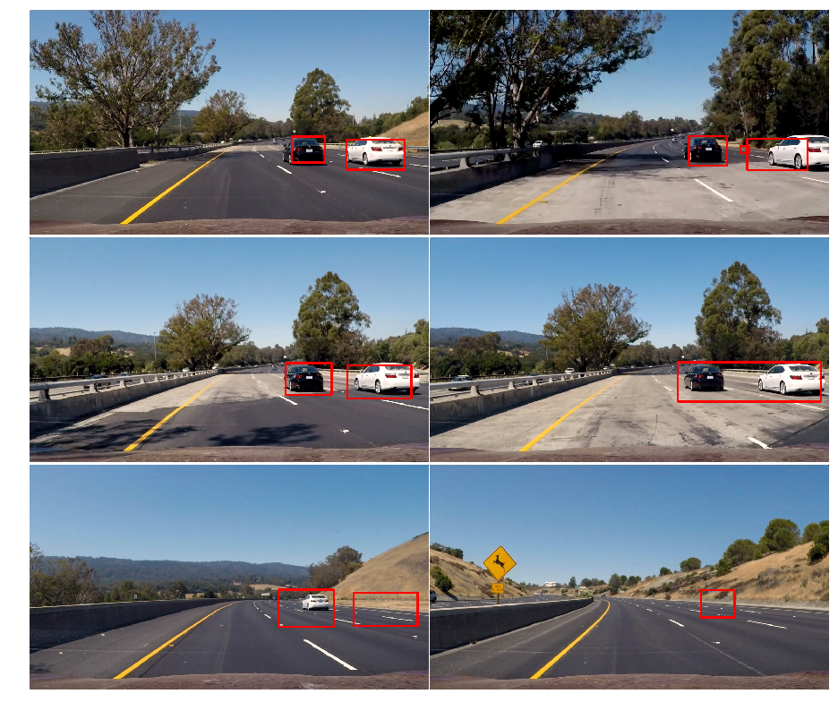

```python
test_images = glob.glob('./test_images/test*.jpg')

fig, axs = plt.subplots(3, 2, figsize=(16,14))
fig.subplots_adjust(hspace = .004, wspace=.002)
axs = axs.ravel()

for i, im in enumerate(test_images):
    axs[i].imshow(frame_proc(mpimg.imread(im)))
    axs[i].axis('off')
```

## Video Creation

```python
def video_image(img):
    return frame_proc(img, video=True, lane=True)
```

### But first...

It'd be fun to combine the lane lines project with this one :)

A few edits in the frame_proc function later...

```python
# in order to import the lanelines notebook as a module
import sys
import io, os, sys, types
import nbformat

from IPython import get_ipython
from IPython.core.interactiveshell import InteractiveShell

def find_notebook(fullname, path=None):
    """find a notebook, given its fully qualified name and an optional path

    This turns "foo.bar" into "foo/bar.ipynb"
    and tries turning "Foo_Bar" into "Foo Bar" if Foo_Bar
    does not exist.
    """
    name = fullname.rsplit('.', 1)[-1]
    if not path:
        path = ['']
    for d in path:
        nb_path = os.path.join(d, name + ".ipynb")
        if os.path.isfile(nb_path):
            return nb_path
        # let import Notebook_Name find "Notebook Name.ipynb"
        nb_path = nb_path.replace("_", " ")
        if os.path.isfile(nb_path):
            return nb_path


class NotebookLoader(object):
    """Module Loader for IPython Notebooks"""
    def __init__(self, path=None):
        self.shell = InteractiveShell.instance()
        self.path = path

    def load_module(self, fullname):
        """import a notebook as a module"""
        path = find_notebook(fullname, self.path)

        print ("importing notebook from %s" % path)

        # load the notebook object
        nb = nbformat.read(path, as_version=4)


        # create the module and add it to sys.modules
        # if name in sys.modules:
        #    return sys.modules[name]
        mod = types.ModuleType(fullname)
        mod.__file__ = path
        mod.__loader__ = self
        mod.__dict__['get_ipython'] = get_ipython
        sys.modules[fullname] = mod

        # extra work to ensure that magics that would affect the user_ns
        # actually affect the notebook module's ns
        save_user_ns = self.shell.user_ns
        self.shell.user_ns = mod.__dict__

        try:
            for cell in nb.cells:
                if cell.cell_type == 'code':
                    # transform the input to executable Python
                    code = self.shell.input_transformer_manager.transform_cell(cell.source)
                    # run the code in themodule
                    exec(code, mod.__dict__)
        finally:
            self.shell.user_ns = save_user_ns
        return mod

class NotebookFinder(object):
    """Module finder that locates IPython Notebooks"""
    def __init__(self):
        self.loaders = {}

    def find_module(self, fullname, path=None):
        nb_path = find_notebook(fullname, path)
        if not nb_path:
            return

        key = path
        if path:
            # lists aren't hashable
            key = os.path.sep.join(path)

        if key not in self.loaders:
            self.loaders[key] = NotebookLoader(path)
        return self.loaders[key]

sys.meta_path.clear()
sys.meta_path.append(NotebookFinder())
print(sys.meta_path)
from lanelines import imgprocline
```

```
[<__main__.NotebookFinder object at 0x14ab44828>]
importing notebook from lanelines.ipynb
```

```python
print(imgprocline)
```

```
<function imgprocline at 0x14aeec378>
```

```python
test_out_file = 'test_video_out.mp4'
clip_test = VideoFileClip('test_video.mp4')
clip_test_out = clip_test.fl_image(video_image)
%time clip_test_out.write_videofile(test_out_file, audio=False)
```

```
[MoviePy] >>>> Building video test_video_out.mp4
[MoviePy] Writing video test_video_out.mp4
```

```
[MoviePy] Done.
[MoviePy] >>>> Video ready: test_video_out.mp4

CPU times: user 13.9 s, sys: 2.23 s, total: 16.1 s
Wall time: 14.5 s
```

```python
project_out_file = 'project_video_out.mp4'
clip_test = VideoFileClip('project_video.mp4')
clip_test_out = clip_test.fl_image(video_image)
%time clip_test_out.write_videofile(project_out_file, audio=False)
```

```
[MoviePy] >>>> Building video project_video_out.mp4
[MoviePy] Writing video project_video_out.mp4
```

```
[MoviePy] Done.
[MoviePy] >>>> Video ready: project_video_out.mp4

CPU times: user 6min 55s, sys: 1min 14s, total: 8min 9s
Wall time: 6min 55s
```